# Basic Inferential Data Analysis

Clément Brutti-Mairesse

27/04/2020

## About the dataset

We make an analysis on an experiment made on 60 pigs, trying to find the effect of `Orange Juice` and `Ascorbic Acid` on tooth growth. The metric is the length of odontoblast, evaluated in milligrams/day.

## Exploratory Data Analysis

Here is a table with the count, variance, quartiles of each group.

```r
data <- ToothGrowth
levels(data$supp) <- c("Orange Juice", "Ascorbic Acid")
groupData <- data %>% group_by(supp, dose)
kable(groupData %>% summarise(n = n(),  mean = mean(len), variance = var(len),
                              q25 = quantile(len)[2],
                              median = quantile(len)[3],
                              q75 = quantile(len)[4],
                              skewness = skewness(len),
                              kurtosis = kurtosis(len)))
```

| supp | dose | n | mean | variance | q25 | median | q75 | skewness | kurtosis |
| --- | --- | --- | --- | --- | --- | --- | --- | --- | --- |
| Orange Juice | 0.5 | 10 | 13.23 | 19.889000 | 9.700 | 12.25 | 16.175 | 0.4381154 | -1.3697072 |
| Orange Juice | 1.0 | 10 | 22.70 | 15.295556 | 20.300 | 23.45 | 25.650 | -0.6804992 | -0.6799774 |
| Orange Juice | 2.0 | 10 | 26.06 | 7.049333 | 24.575 | 25.95 | 27.075 | 0.3685108 | -1.0857354 |
| Ascorbic Acid | 0.5 | 10 | 7.98 | 7.544000 | 5.950 | 7.15 | 10.900 | 0.1330745 | -1.8068950 |
| Ascorbic Acid | 1.0 | 10 | 16.77 | 6.326778 | 15.275 | 16.50 | 17.300 | 0.9255236 | 0.0762364 |
| Ascorbic Acid | 2.0 | 10 | 26.14 | 23.018222 | 23.375 | 25.95 | 28.800 | 0.1605264 | -1.2320527 |

We can already see that groups do not have the same variance.

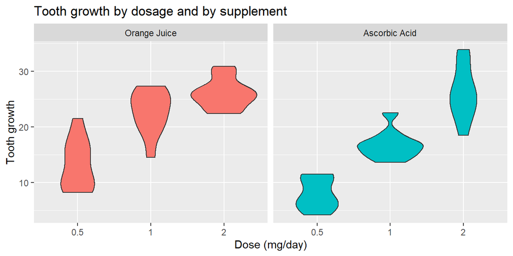

```r
ggplot(data, aes(x=factor(dose), y=len)) +
 facet_grid(.~supp) +
 geom_violin(aes(fill = supp), show.legend = FALSE) +
 labs(title="Tooth growth by dosage and by supplement",
      x="Dose (mg/day)",
      y="Tooth growth")
```

## Growth analysis

We now compare the six different groups with themselves. We suppose this is a randomized experiment, and that the groups are independents and that the variance is **not** constant between groups. We use a 95% T confidence interval to compare the groups. Here is a reminder of the detail of the t confidence interval calculation with an unequal variance, (we use `t.test(, var.equal=FALSE)`)
$$\bar{Y} - \bar{X} \pm
t_{df} \times ({s^2_x \over n_x} + {s^2_y \over n_y})^{1/2}$$

with $t_{df}$ : $t$ quantile and $df$ equals to
$$df = {
(S^2_x / n_x + S^2_y / n_y)^2
\over
(S^2_x / n_x)^2 / (n_x - 1) +
(S^2_y / n_y)^2 / (n_y - 1)
}$$

Here is a table summing up the confidence intervals. Rows are compared with columns. For example: *Orange Juice 2mg/day* (OJ 2) is `15.8 to 20.36` mg/day better than *Ascorbic Acid 0.5mg/day* (AA 0.5).

|  | OJ 0.5 | OJ 1 | OJ 2 | AA 0.5 | AA 1 | AA 2 |
| --- | --- | --- | --- | --- | --- | --- |
| OJ 0.5 | NA | [-14.62;-4.325] | [-16.7;-8.956] | [1.263;9.237] | [-6.706;-0.374] | [-18.26;-7.562] |
| OJ 1 | [4.325;14.62] | NA | [-7.271;0.5509] | [12;17.44] | [1.952;9.908] | [-6.848;-0.03218] |
| OJ 2 | [8.956;16.7] | [-0.5509;7.271] | NA | [15.8;20.36] | [6.833;11.75] | [-4.329;4.169] |
| AA 0.5 | [-9.237;-1.263] | [-17.44;-12] | [-20.36;-15.8] | NA | [-12.03;-5.55] | [-22.36;-13.96] |
| AA 1 | [0.374;6.706] | [-9.908;-1.952] | [-11.75;-6.833] | [5.55;12.03] | NA | [-13.33;-5.405] |
| AA 2 | [7.562;18.26] | [0.03218;6.848] | [-4.169;4.329] | [13.96;22.36] | [5.405;13.33] | NA |

Similarly, this a table sum up the p-Values in percentage

|  | OJ 0.5 | OJ 1 | OJ 2 | AA 0.5 | AA 1 | AA 2 |
| --- | --- | --- | --- | --- | --- | --- |
| OJ 0.5 | NA | 0.24% | 0.0037% | 1.5% | 3.2% | 0.04% |
| OJ 1 | 0.24% | NA | 8.4% | 6.6e-05% | 0.82% | 4.8% |
| OJ 2 | 0.0037% | 8.4% | NA | 2.4e-06% | 0.0013% | 97% |
| AA 0.5 | 1.5% | 6.6e-05% | 2.4e-06% | NA | 0.017% | 0.00043% |
| AA 1 | 3.2% | 0.82% | 0.0013% | 0.017% | NA | 0.046% |
| AA 2 | 0.04% | 4.8% | 97% | 0.00043% | 0.046% | NA |